# Effective And Honest Scales

# Goal

This notebook shows how scale choices affect interpretation.

# Analytic Questions

- How can axis limits exaggerate or reduce apparent differences?
- When should a scale start at zero?
- How do we show a focused comparison without misleading the reader?

# Load Data

```r
flu <- readr::read_csv("data/real/flu_vaccination_age_time_clean.csv")
```

# Prepare Data

| Data preparation step | Functions in this chunk |
| --- | --- |
| Keep or remove rows | `filter()` |

```r
us_may <- flu |>
  filter(
    geography == "United States",
    month == 5,
    age_group %in% c("18-49 Years", "50-64 Years", ">=65 Years"),
    !is.na(estimate)
  )
```

# Focusing In

`coord_cartesian()` zooms the displayed y-axis without removing rows from the data.

| Plot component | Code in this chunk |
| --- | --- |
| Aesthetic mappings | `x`; `y`; `color` |
| Geoms / stats | `geom_line()`; `geom_point()` |
| `geom_line()` properties | `linewidth` |
| `geom_point()` properties | `size` |
| Scales / coordinates / facets / labels | `coord_cartesian()`; `labs()`; `theme_minimal()` |

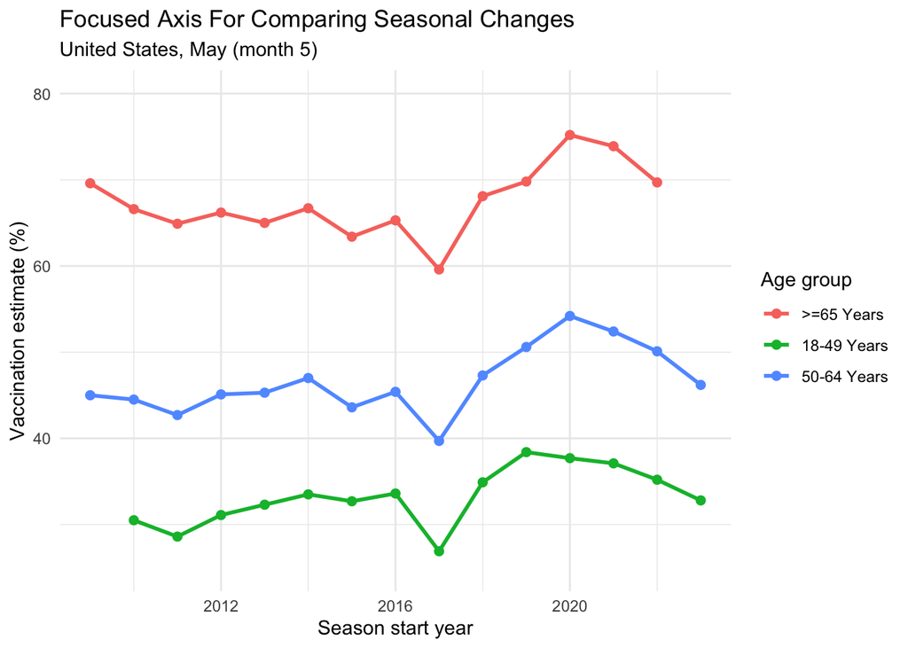

```r
p1 <- ggplot(us_may, aes(x = season_start_year, y = estimate, color = age_group)) +
  geom_line(linewidth = 1) +
  geom_point(size = 2) +
  coord_cartesian(ylim = c(25, 80))

p2 <- p1 +
  labs(
    title = "Focused Axis For Comparing Seasonal Changes",
    subtitle = "United States, May (month 5)",
    x = "Season start year",
    y = "Vaccination estimate (%)",
    color = "Age group"
  ) +
  theme_minimal()

p2
```

The focused axis makes year-to-year changes easier to see. That being said, zooming to “frame” the data is not always desirable. There are times when it is useful to contain certain values which may not be contained in the data. Use your judgment.

# Framing Based Upon A Benchmark

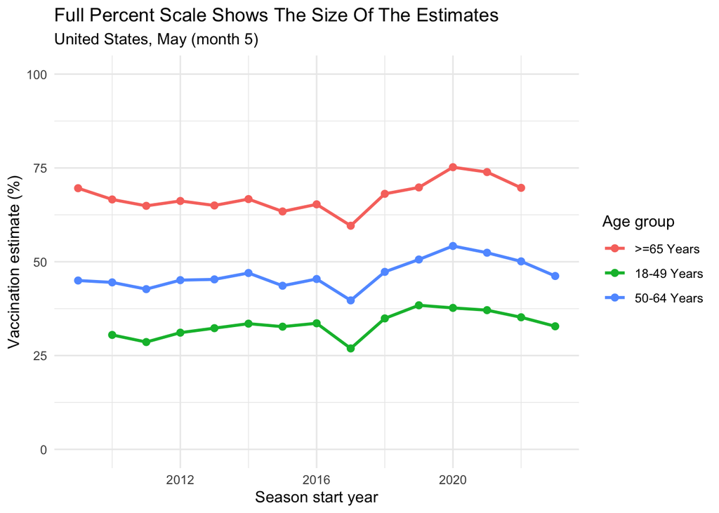

```r
p1 <- ggplot(us_may, aes(x = season_start_year, y = estimate, color = age_group)) +
  geom_line(linewidth = 1) +
  geom_point(size = 2) +
  coord_cartesian(ylim = c(0, 100))

p2 <- p1 +
  labs(
    title = "Full Percent Scale Shows The Size Of The Estimates",
    subtitle = "United States, May (month 5)",
    x = "Season start year",
    y = "Vaccination estimate (%)",
    color = "Age group"
  ) +
  theme_minimal()

p2
```

The full 100% scale makes the absolute level clearer, but compresses small changes. I think this is an example where keeping the whole range of possible y-axis values is superior to zooming in.

# Same Data, Different Scale

The same data can look very different when the y-axis changes. This example uses a rare adverse event: 0.001% in standard care and 0.003% in a new treatment group.

The relative difference is real: the event is three times as common in the new treatment group. But the absolute risk is still very small.

| Data preparation step | Functions in this chunk |
| --- | --- |
| Create or change columns | `mutate()` |

```r
adverse_event_risk <- tibble::tibble(
  treatment = c("Standard care", "New treatment"),
  risk = c(0.00001, 0.00003)
) |>
  mutate(
    treatment = factor(treatment, levels = treatment),
    risk_label = scales::percent(risk, accuracy = 0.001)
  )
```

# Tight Scale

This plot is not strictly speaking inaccurate, but it is misleading. It makes a tiny absolute risk look visually large because the y-axis only covers a very small range.

| Plot component | Code in this chunk |
| --- | --- |
| Aesthetic mappings | `x`; `y`; `label` |
| Geoms / stats | `geom_col()`; `geom_text()` |
| `geom_col()` properties | `fill`; `width` |
| `geom_text()` properties | `size` |
| Scales / coordinates / facets / labels | `scale_y_continuous()`; `labs()`; `theme_minimal()` |

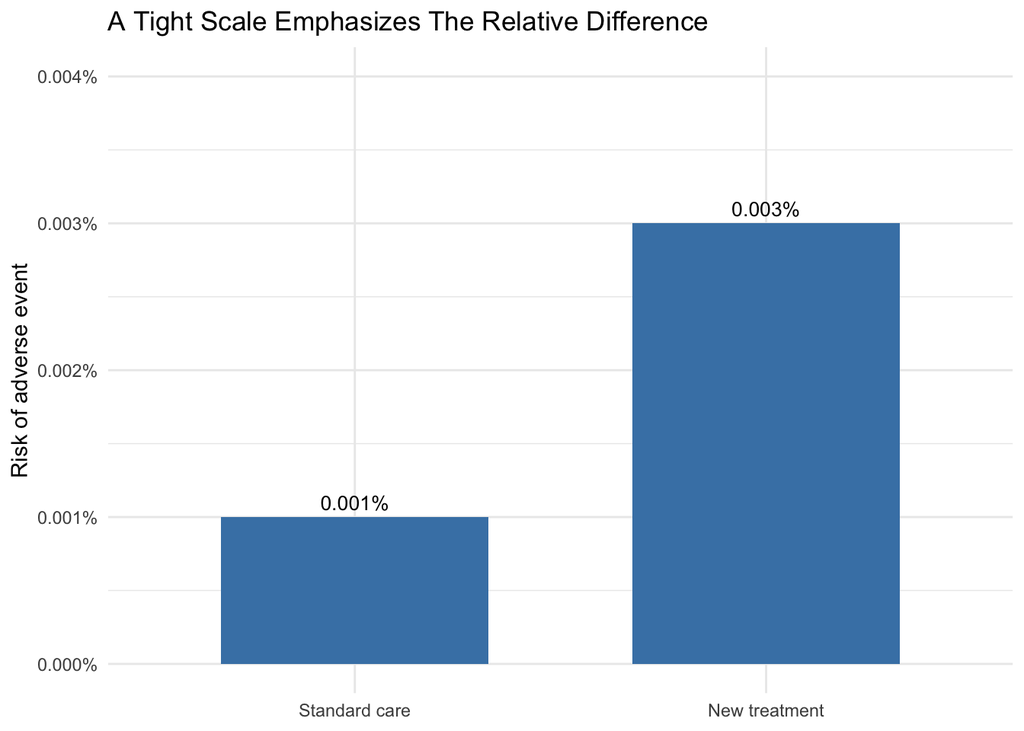

```r
ggplot(adverse_event_risk, aes(x = treatment, y = risk)) +
  geom_col(fill = "steelblue", width = 0.65) +
  geom_text(aes(label = risk_label), vjust = -0.5, size = 3.5) +
  scale_y_continuous(
    limits = c(0, 0.00004),
    labels = scales::label_percent(accuracy = 0.001)
  ) +
  labs(
    title = "A Tight Scale Emphasizes The Relative Difference",
    x = NULL,
    y = "Risk of adverse event"
  ) +
  theme_minimal()
```

# Full Probability Scale

The same data on a full probability scale tells a different story. The relative difference still exists, but the absolute risk is tiny.

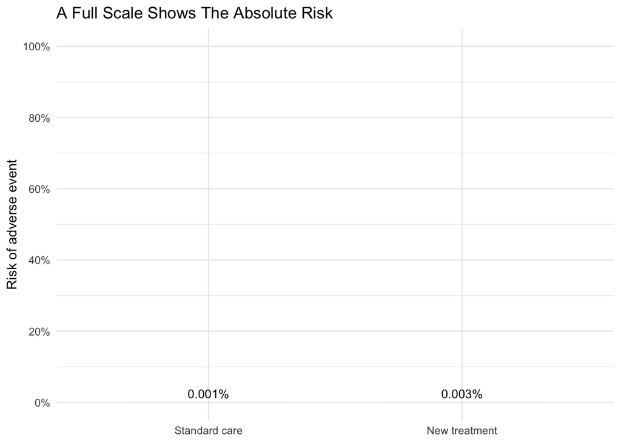

```r
ggplot(adverse_event_risk, aes(x = treatment, y = risk)) +
  geom_col(fill = "steelblue", width = 0.65) +
  geom_text(aes(label = risk_label), vjust = -0.5, size = 3.5) +
  scale_y_continuous(
    limits = c(0, 1),
    breaks = seq(0, 1, 0.2),
    labels = scales::label_percent(accuracy = 1)
  ) +
  labs(
    title = "A Full Scale Shows The Absolute Risk",
    x = NULL,
    y = "Risk of adverse event"
  ) +
  theme_minimal()
```

Neither plot changes the data. The question is what readers need to understand: the relative increase, the absolute risk, or both.

# Bars Usually Need Zero

| Data preparation step | Functions in this chunk |
| --- | --- |
| Keep or remove rows | `filter()` |
| Create or change columns | `mutate()` |

| Plot component | Code in this chunk |
| --- | --- |
| Aesthetic mappings | `x`; `y` |
| Geoms / stats | `geom_col()` |
| `geom_col()` properties | `fill` |
| Scales / coordinates / facets / labels | `coord_flip()`; `labs()`; `theme_minimal()` |

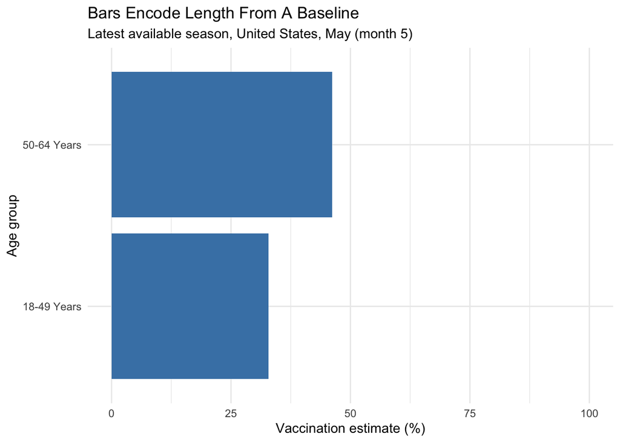

```r
latest <- us_may |>
  filter(season_start_year == max(season_start_year)) |>
  mutate(age_group = reorder(age_group, estimate))

p1 <- ggplot(latest, aes(x = age_group, y = estimate)) +
  geom_col(fill = "steelblue") +
  coord_flip(ylim = c(0, 100))

p2 <- p1 +
  labs(
    title = "Bars Encode Length From A Baseline",
    subtitle = "Latest available season, United States, May (month 5)",
    x = "Age group",
    y = "Vaccination estimate (%)"
  ) +
  theme_minimal()

p2
```

# Takeaways

- For line plots, a narrowed y-axis can help compare change, but the title, subtitle, or caption should make the axis range obvious.
- Percent scales often need context for the full 0-100 range.
- Tight scales can emphasize relative differences, but readers may also need absolute-risk context.
- Bars encode length from a baseline, so zero usually matters.
- Do an honesty gut-check: is this scale the most honest way to convey the data/findings?